# Ch3_homework_2016-09-20

Stacey Harmer

September 20, 2016

First, run code for the easy problems

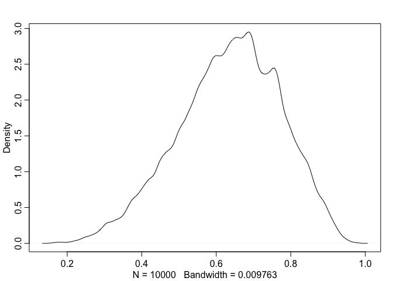

```r
library(rethinking)
p_grid <- seq( from=0 , to=1 , length.out=1000 )
prior <- rep( 1 , 1000 )
likelihood <- dbinom( 6 , size=9 , prob=p_grid )
posterior <- likelihood * prior
posterior <- posterior / sum(posterior)
set.seed(100)
samples <- sample( p_grid , prob=posterior , size=1e4 , replace=TRUE )

dens(samples) # looks good
```

## 3E1

How much probability lies below p = 0.2?

```r
sum(samples < 0.2) / 1e4 # 5 e-4 probability mass below p of .2
```

```
## [1] 5e-04
```

## 3E2

How much probability lies above p = 0.8?

```r
sum(samples > 0.8) / 1e4 # 0.1117
```

```
## [1] 0.1117
```

## 3E3

How much posterior probability lies between p = 0.2 and p = 0.8??

```r
sum(samples>0.2 & samples <=0.8) / 1e4 # .8878
```

```
## [1] 0.8878
```

## 3E4

20% of the posterior probability lies below which value of p??

```r
quantile(samples, 0.2) # 0.5195195
```

```
##       20%
## 0.5195195
```

## 3E5

20% of the posterior probability lies above which value of p?

```r
quantile(samples, 0.8) # above 0.76
```

```
##       80%
## 0.7567568
```

## 3E6

Which values of p contain the narrowest interval equal to 66% of the posterior probability?

```r
HPDI(samples, p= .66) # 0.5205205   to   0.7847848
```

```
##     |0.66     0.66|
## 0.5205205 0.7847848
```

## 3E7

Which values of p contain 66% of the posterior probability, assuming equal posterior probability both below and above the interval?

```r
PI(samples, p= .66) # 0.5005005    to   0.7687688
```

```
##       17%       83%
## 0.5005005 0.7687688
```

## 3M1

Globe tossing, now 8 water in 15 tosses. Use grid approx to construct posterior distribution (flat prior).

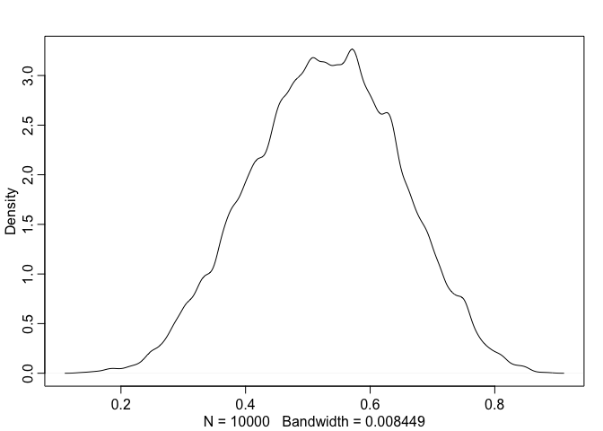

```r
p_grid <- seq( from=0 , to=1 , length.out=1000 )
prior <- rep( 1 , 1000 )
likelihood <- dbinom( 8, size=15 , prob=p_grid )
posterior.2 <- likelihood * prior
posterior.2 <- posterior.2 / sum(posterior.2)
set.seed(100)
samples.2 <- sample( p_grid , prob=posterior.2 , size=1e4 , replace=TRUE )

dens(samples.2) # looks good
```

## 3M2

Draw 10,000 samples from the grid approximation from above. Then use the samples to calculate the 90% HPDI for p

```r
samples.2 <- sample( p_grid , prob=posterior.2 , size=1e4 , replace=TRUE )
HPDI(samples.2, prob = 0.9)  # 0.3383383 to  0.7317317
```

```
##      |0.9      0.9|
## 0.3383383 0.7317317
```

## 3M3

Construct a posterior predictive check for this model and data. This means simulate the distribution of samples, averaging over the posterior uncertainty in p. What is the probability of observing 8 water in 15 tosses?

To check model, use samples from posterior as range of values for p

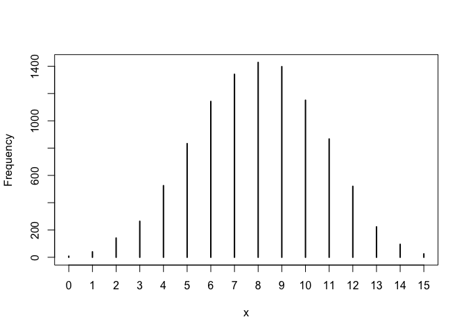

```r
test.mod <- rbinom( 1e4 , size=15 , prob=samples.2 )
# now how often is the value 8 observed?
simplehist(test.mod) # it is the most probable outcome
```

```r
sum(test.mod ==8)/1e4 # but still 0.1428, or 14.3% of time
```

```
## [1] 0.1428
```